# Trianglular Interpolation & Time/Location Matching

- Show All Code
- Hide All Code
- View Source

Approach for Fast Interpolation of Values within FVCOM Mesh

Published

July 29, 2024

```r
# Packages
library(raster)        # netcdf data as raster
library(sf)            # vector spatial mapping/operations
library(fvcom)         # fvcom mesh and variable extractions
library(ncdf4)         # netcdf support
library(tidyverse)     # data wrangling and plotting
library(gmRi)          # color schemes and cloud storage paths
library(patchwork)     # plot arrangement
library(rnaturalearth) # coastlines and state polygons
library(geometry)      # bathycentric coordinates
library(Matrix)        # matrix algebra
library(sysfonts)      # font support



# Paths + conflicts
conflicted::conflict_prefer("select", "dplyr")
conflicted::conflict_prefer("filter", "dplyr")
proj_path <- cs_path("mills", "Projects/Lobster ECOL")
# fvcom_out <- str_c(proj_path, "FVCOM_support/")

source(here::here("R/FVCOM_Support.R"))



# Load a maine polygon
maine <- ne_states("united states of america", returnclass = "sf") %>%
  filter(postal %in% c("ME", "NH", "MA", "CT", "RI", "VT"))


# Gom EPU to clip
res_shapes <- cs_path("res", "Shapefiles")
epu_path <- str_c(res_shapes, "EPU/")
gom_poly <- read_sf(str_c(epu_path, "individual_epus/GOM.geojson"))
```

```r
# Use GMRI style
use_gmri_style_rmd()
```

# Approaches to Interpolate Values within Triangular Mesh

Calculating values for points within the FVCOM mesh involves some sort of interpolation. Potential approaches for achieving this may exclusively incorporate local information from the three nearest nodes (ex. nearest neighbor, local inverse distance weighting, barycentric coordinates) or instead model variance over changing distance using information across many nodes (ex. Inverse Distance Weighting IDW, Kriging).

This quarto explores the application of **Barycentric Interpolation** to interpolate values at many point locations across the FVCOM mesh area. This approach takes information from the three surrounding nodes and interpolates a value based on barycentric coordinate weights. This is a deterministic approach that should perform quickly without overdue computational burdens and avoid decision making processes around parameter tuning.

To achieve this, the workflow needs to identify the triangle that the point falls within, and extract from the source NetCDF file the variable values for the relevant three nodes of that triangle.

To demonstrate the approach the following 100 points have been simulated at random. They occur during the time period that FVCOM’s GOM3 mesh was in use, which we will use as the mesh for testing below.

```r
# Make a dataframe of random points
set.seed(123)
point_number <- 100
pts_df <- data.frame(
  pt_id = str_c("station_", seq(1, point_number)),
  lon = rnorm(point_number, mean = -68.5, sd = 0.3),
  lat = rnorm(point_number, mean = 43.2, sd = 0.3),
  dtime = seq.Date(as.Date("2014-01-09"), as.Date("2016-06-12"), length.out = point_number)) %>%
  st_as_sf(coords = c("lon", "lat"), crs = 4326, remove = FALSE)
```

The [fvcom](https://github.com/BigelowLab/fvcom/tree/68566ac2c161bde1f549d6157dc69cee2fc8e704) package created by Ben Tupper. The `fvcom::get_mesh_geometry` function provides functionality for constructing a simple feature collection for the FVCOM mesh which can be used for spatial operations. This simple features collection importantly includes point and element ID #’s that can be used to label which trianglar regions in the mesh should be associated with the points we wish to interpolate at.

[FVCOM monthly-average hindcast data](http://www.smast.umassd.edu:8080/thredds/catalog/models/fvcom/NECOFS/Archive/Seaplan_33_Hindcast_v1/monthly_mean/catalog.html) will be used as our data source for constructing/using the mesh geometry.

```r
# Load some daily FVCOM that we downloaded and averaged
daily_fpath <- cs_path("mills", "Projects/Lobster ECOL/FVCOM_processed/GOM3_daily")
gom3_2014 <- read_csv(str_c(daily_fpath, "GOM3_daily_surfbottemp_2014_01.csv"))
gom3_oneday <- gom3_2014 %>% filter(date == "2014-01-01")


# Get some file names to load monthly files
gom3_files <- monthly_fvcom_inventory(
  start_yr = 2014,
  end_yr = 2014,
  fvcom_folder = cs_path("res", "FVCOM/monthly_means"),
  fvcom_vers = "GOM3")

# Open one
gom3_early <- nc_open(gom3_files[[1]])


# Get the mesh itself as a simple feature collection
gom3_mesh <- get_mesh_geometry(gom3_early, what = 'lonlat')
```

Below is a map of our simulated test locations and where they fall within the context of the FVCOM mesh within the Gulf of Maine Ecological Production Unit.

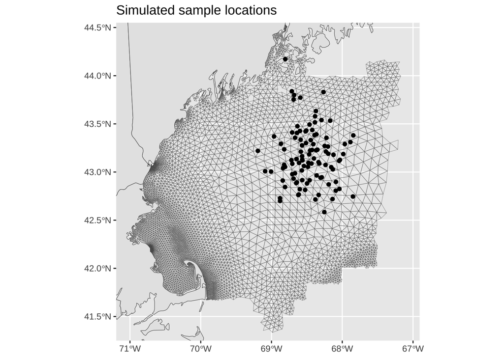

```r
# Prep CRS to clip
gom_poly <- st_transform(gom_poly, st_crs(gom3_mesh))

# Flag the locations that are within the domain
gom_mesh <- gom3_mesh %>%
    st_join(gom_poly, join = st_within) %>%
    drop_na(EPU) %>%
    dplyr::select(-c(EPU, Shape_Leng, Shape_Area, source))


# Plot them all
ggplot() +
  geom_sf(data = gom_mesh, alpha = 0.1, linewidth = 0.1) +
  geom_sf(data = maine) +
  geom_sf(data = pts_df) +
  coord_sf(xlim = c(-71, -67.1), ylim = c(41.4, 44.4)) +
  labs(title = "Simulated sample locations")
```

# Step 1: Triangle Overlap Point-Matching

Since the mesh is static, we can use any time index to pull their locations and identify which triangles are associate with which points.

This operation can be performed for all points in one step using `sf::st_join(, join = st_within)`.

Once the three relevant nodes are identified we can calculate barycentric coordinates which can be used to weight the values at each node.

```r
# We can use the mesh from Ben's function as the lookup table,
# and elem numbers as triangle ID's
# A bonus of going this route is that NODE and element ID numbers match ncvar_get index order

# The mesh
gom3_mesh <- get_mesh_geometry(gom3_early, what = 'lonlat')


# We can also pull lon + lat from the netcdf as well and index that way
gom3_coords <- data.frame(
    "lon" = ncvar_get(gom3_early, "lon"),
    "lat" = ncvar_get(gom3_early, "lat")) %>%
  mutate(node_id = row_number(), .before = "lon")


# 1. Get the triangle and its nodes that overlap
# Use st_join to assign elem to the points and their we're looking up
# The geometry is still the point here, but now we know the element and point indices
pts_assigned <- st_join(
  st_transform(pts_df, st_crs(gom3_mesh)),
  gom3_mesh,
  join = st_within)
```

The following plot/code verifies that the random points indeed fall within the triangle they are matched to, and that the node ID’s from that triangle match the index order of `ncvar_get()` for lat/lon based variables.

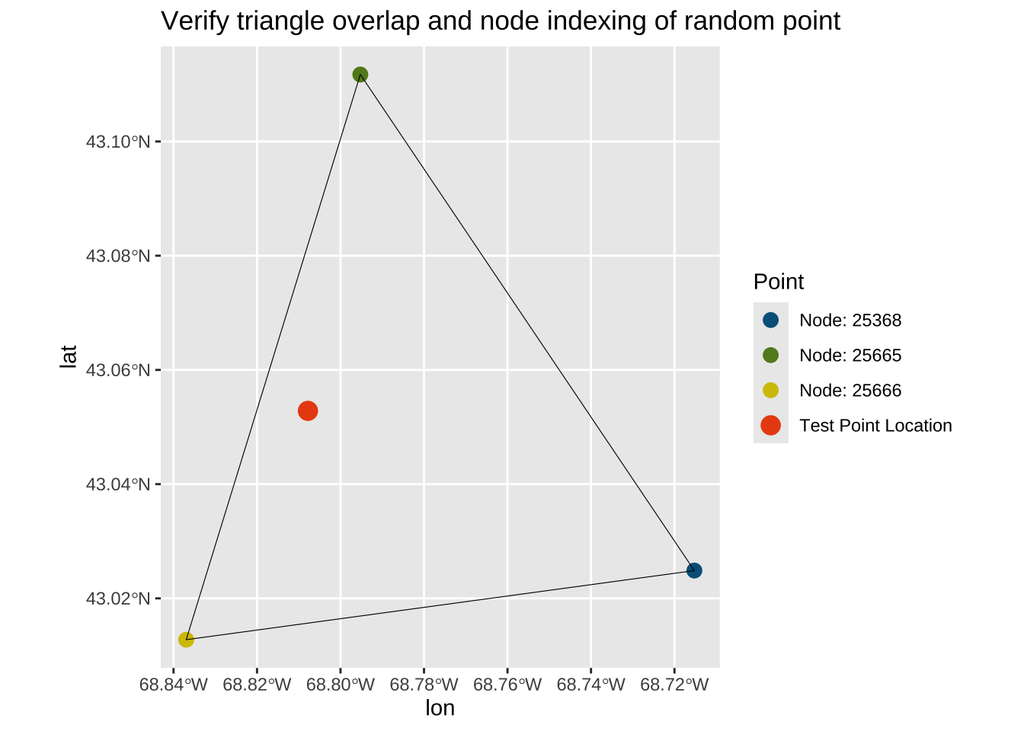

```r
#### Sandbox Testing:

# # Are the coordinates even different if projected to NAD83 or not? don't think so...
# Ignore for now
# pts_assigned %>% st_coordinates()  %>% bind_cols(pts_df) %>% transmute(x_diff = lon - X, y_diff = lat - Y)

# 2. Option 1: Use triangle index to pull node coordinates
# We can use the triangles to pull coordinates from the sf geometries
# What we really want are the point coordinates for barycentric distances
# remember, lon & lat come in pairs so the index number grabs both... i think
triangle_matches <- gom3_mesh[pts_assigned$elem,]

# Nodes for one triangle
# st_coordinates(triangle_matches[1,])[1:3,]

# Do they also match the daily data row indices?
# Hell yea, they do in space
# need to triple check the order is fine
# Seems Good!
row_idx <- sample(c(1:nrow(pts_assigned)), size = 1, replace = F )
pt1_id = triangle_matches[row_idx, "p1"] %>% st_drop_geometry() %>% as.numeric()
pt2_id = triangle_matches[row_idx,"p2"] %>% st_drop_geometry() %>% as.numeric()
pt3_id = triangle_matches[row_idx,"p3"] %>% st_drop_geometry() %>% as.numeric()
ggplot() +
  geom_point(data = gom3_oneday[pt1_id,], aes(lon, lat, color = str_c("Node: ", pt1_id)), size = 3) +
  geom_point(data = gom3_oneday[pt2_id,], aes(lon, lat, color = str_c("Node: ", pt2_id)), size = 3) +
  geom_point(data = gom3_oneday[pt3_id,], aes(lon, lat, color = str_c("Node: ", pt3_id)), size = 3) +
  geom_point(data = pts_assigned[row_idx,], aes(lon, lat, color = "Test Point Location"), size = 4) +
  scale_color_gmri() +
  geom_sf(data = triangle_matches[row_idx, ], color = "black", fill = NA, size = 1) +
  labs(color = "Point",
       title = "Verify triangle overlap and node indexing of random point")
```

```r
# # But we need to  make sure when we get distance the distance goes with the right point
# # are they in order with st_coordinates?
# # This is how we could match to lon;at coords:
# pt_matches_x <- triangle_matches[row_idx, c("p1", "p2", "p3")] %>%
#   st_drop_geometry() %>%
#   t() %>%
#   c()

# # And they do seem to match, sick
# gom3_coords[pt_matches_x,]$lon == st_coordinates(triangle_matches[row_idx,])[1:3,"X"]
# gom3_coords[pt_matches_x,]$lat == st_coordinates(triangle_matches[row_idx,])[1:3,"Y"]
```

### Add node details to points table

After confirming that the point id’s from `fvcom::get_mesh_geometry()` correctly matched with the index order of `ncdf4::ncvar_get()`, we can confidently use those indices to quickly add the lat/lon coordinates of these nodes directly into the dataframe holding the points we wish to interpolate at.

This is purely organizational, and keeps all information together in a single object.

```r
# Objective:
# Get the appropriate x1, x2, x3, y1, y2, y3, values into the "pnts_assigned"
# can use either the mesh or use the lon/lat table,


####  Option 2: Lon/Lat Table

# The table is probably faster
# Though I am worried if i hop between the two I might mix index order... idk
gom3_coords <- data.frame(
    "lon" = ncvar_get(gom3_early, "lon"),
    "lat" = ncvar_get(gom3_early, "lat")) %>%
  mutate(node_id = row_number(),
         .before = "lon")

# This will add relevant coords to the table
pts_with_nearnodes <- pts_assigned %>%
  st_drop_geometry() %>%
  #rowwise() %>%
  mutate(
    x1 = gom3_coords[p1, "lon"],
    x2 = gom3_coords[p2, "lon"],
    x3 = gom3_coords[p3, "lon"],
    y1 = gom3_coords[p1, "lat"],
    y2 = gom3_coords[p2, "lat"],
    y3 = gom3_coords[p3, "lat"]
  )
```

# Step 2: Getting Barycentric Weights

To interpolate variable values within the triangle we now need barycentric coordinate weights. Now  
that we know where points fall and the coordinates for those points, we now just with their barycentric coordinates which will be used as weights.

This is how we can get the weights using the first point-triangle match:

```r
# So All I Really Wanted was this....
triangle_coord_test <- triangle_matches[1,] %>% st_coordinates()
triangle_coord_test <- triangle_coord_test[c(1:3), c(1:2)]

# So take the simplex from the first one, and also the point coords
simplex_test <- as.matrix(triangle_coord_test)
point_test <- pts_assigned[1, c("lon", "lat")] %>% st_drop_geometry() %>% as.matrix()

# If we have the rownames in the simplex they will confirm which weights go with these values
as.data.frame(cart2bary(
  X = simplex_test,
  P = point_test)) %>%
  setNames(triangle_matches[1,c("p1", "p2", "p3")] %>%
             st_drop_geometry())
```

| 25073 | 25074 | 25368 |
| --- | --- | --- |
| 0.1209655 | 0.3431237 | 0.5359108 |

### Assign Barycentric Weights

All the points can be done in row-wise operation this way. There definitely is a faster way to do this, but remember that we only need to do this once since the mesh doesn’t really change.

```r
# adapted from this, doesn't use trisearch
# https://www.r-bloggers.com/2013/03/barycentric-interpolation-fast-interpolation-on-arbitrary-grids/




# Function to do it for each unique row, fails if not unique
barycentric_weights_from_row <- function(coordinates_df){


    # Make the simplex
    nodes_simplex <- matrix(
      as.numeric(c(coordinates_df[c("x1", "x2", "x3", "y1", "y2", "y3")])),
      nrow = 3)
    node_indices <- coordinates_df[c("p1", "p2", "p3")]
    colnames(nodes_simplex) <- c("X", "Y")
    rownames(nodes_simplex) <- node_indices

    # Make matrix from the points:
    point_mat <- as.matrix(coordinates_df[1, c("lon", "lat")])

    # Get the coords
    bcoords_x <- as.data.frame(cart2bary(nodes_simplex, point_mat)) %>%
      setNames(c("p1_bary", "p2_bary", "p3_bary"))

    # Return with dataframe
    bind_cols(coordinates_df, bcoords_x)

}

# # Test why it doesn't work:
# coordinates_df <- pts_with_nearnodes %>%
#   split(.$pt_id) %>%
#   pluck(1)
# barycentric_weights_from_row(coordinates_df = coordinates_df)
# rm(coordinates_df)

# Actually get all the weights
overlaid_barycentric_weights <- pts_with_nearnodes %>%
  split(.$pt_id) %>%
  map_dfr(barycentric_weights_from_row)

# # Print these
# overlaid_barycentric_weights %>%
#   head() %>%
#   knitr::kable()
```

# Step 3: Interpolate Values using Matrix Algebra

The following code takes the all the information we’ve gathered above and performs the interpolation:

```r
#### Interpolation Code Below  ####


# Apparently: Then we can sparse matrix it if we want fast interpolation...
# # https://www.r-bloggers.com/2013/03/barycentric-interpolation-fast-interpolation-on-arbitrary-grids/

# Define the interpolation as a sparse matrix operation.
# Faster than using apply, probably slower than a C implementation


# # The original code for this:
# M <- sparseMatrix(
#   i    = rep(1:nrow(Xi), each=3),
#   j    = as.numeric(t(active)),
#   x    = as.numeric(t(tri$p)),
#   dims = c(nrow(Xi), length(f)))

# Xi was the df for new points
# Active was the indices for the nodes
# tri$p are the barycentric coords
# f is matrix/array containing the values

# My attempt to apply it to my stuff
# Temperature Values
stemp_vals <- ncvar_get(gom3_early, "temp")[,1]
btemp_vals <- ncvar_get(gom3_early, "temp")[,45]

M <- sparseMatrix(
  i    = rep(1:nrow(overlaid_barycentric_weights), each=3),
  j    = as.numeric(t(overlaid_barycentric_weights[,c("p1", "p2", "p3")])),
  x    = as.numeric(t(overlaid_barycentric_weights[,c("p1_bary", "p2_bary", "p3_bary")])),
  dims = c(nrow(overlaid_barycentric_weights), length(stemp_vals)))


# Matrix Multiply to Interpolate
interp_sst <- as.numeric(M %*% stemp_vals)
interp_bt <- as.numeric(M %*% stemp_vals)
```

### Plot Interpolation Results

The following plot shows the interpolated values for our simulated points, and the nodes used when interpolating values for those points.

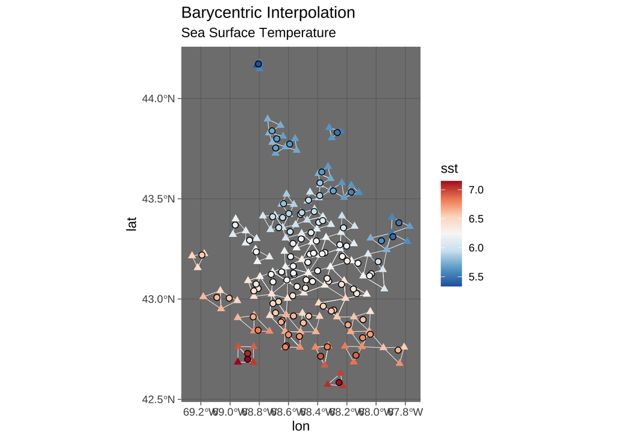

```r
# Combine with the points
interpolated_vals <- bind_cols(
  overlaid_barycentric_weights,
  data.frame("sst" = interp_sst),
  data.frame("bt" = interp_bt)
)


# Values at relevant nodes only
all_nodes <- unique(unlist(overlaid_barycentric_weights[,c("p1", "p2", "p3")]))
node_sst <- data.frame(
  "lon" = gom3_coords[all_nodes, "lon"],
  "lat" = gom3_coords[all_nodes, "lat"],
  "sst" = stemp_vals[all_nodes],
  "bt" = btemp_vals[all_nodes]
)

# Values everywhere:
gom3_early_temps <- bind_cols(
  gom3_coords,
  data.frame("sst" = stemp_vals),
  data.frame("bt" = stemp_vals),
  )



# Plot something, chicken
ggplot() +
  geom_sf(data = triangle_matches, fill = NA, color = "white") +
  geom_point(data = node_sst, aes(lon, lat, color = sst, shape = "Original Mesh"), size = 2, shape = 17) +
  geom_point(data = interpolated_vals, aes(lon, lat, fill = sst, shape = "Interpolated Values"), size = 2, shape = 21, color = "black", show.legend = F) +
  scale_color_distiller(palette = "RdBu") +
  scale_fill_distiller(palette = "RdBu") +
  scale_shape_manual(values = c(17, 21)) +
  theme_dark() +
  labs(title = "Barycentric Interpolation",
       subtitle = "Sea Surface Temperature")
```

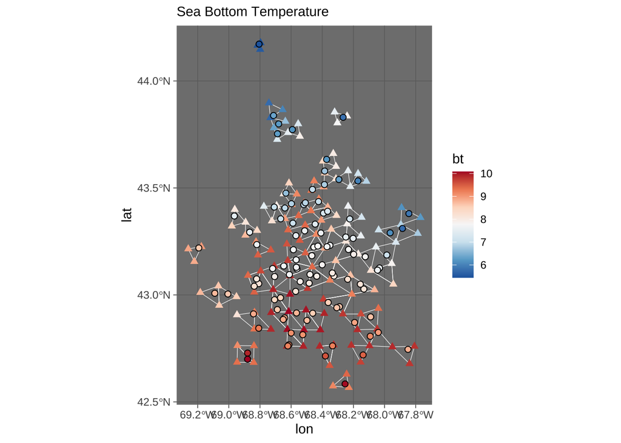

```r
# And bottom temperature:
ggplot() +
  geom_sf(data = triangle_matches, fill = NA, color = "white") +
  geom_point(data = node_sst, aes(lon, lat, color = bt, shape = "Original Mesh"), size = 2, shape = 17) +
  geom_point(data = interpolated_vals, aes(lon, lat, fill = bt, shape = "Interpolated Values"), size = 2, shape = 21, color = "black", show.legend = F) +
  scale_color_distiller(palette = "RdBu") +
  scale_fill_distiller(palette = "RdBu") +
  scale_shape_manual(values = c(17, 21)) +
  theme_dark() +
  labs(subtitle = "Sea Bottom Temperature")
```

# Full Test: Regular Grid Interpolation

One useful application of this approach is to convert from the irregular grid to a more regularly spaced grid. This may be useful for un-biased polygon overlays or for direct comparison with a regularly spaced product.

Another application of this approach is to convert from the more dense meshes of newer FVCOM versions like FVCOM-GOM5 to the sparser GOM3 mesh which has longer temporal coverage.

The following is what a regularly spaced resolution similar to GLORYs (1/12th * 1/12th degree) looks like.

```r
# Make a Regular Grid
reg_grid <- expand.grid(
  lon = seq(-75.75, -56.75, 0.083),
  lat = seq(35.25, 46.25, 0.083)) %>%
  as.data.frame() %>%
  mutate(coord_pair = row_number(), .before = "lon") %>%
  st_as_sf(coords = c("lon", "lat"), crs = 4326, remove = FALSE)


# Use st_join to assign elem to the points and their we're looking up
pts_assigned <- st_join(
  st_transform(reg_grid, st_crs(gom3_mesh)),
  gom3_mesh,
  join = st_within) %>%
  drop_na(elem, p1, p2, p3)


# This will add relevant coords to the table
pts_with_nearnodes <- pts_assigned %>%
  st_drop_geometry() %>%
  mutate(
    x1 = gom3_coords[p1, "lon"],
    x2 = gom3_coords[p2, "lon"],
    x3 = gom3_coords[p3, "lon"],
    y1 = gom3_coords[p1, "lat"],
    y2 = gom3_coords[p2, "lat"],
    y3 = gom3_coords[p3, "lat"]
  )

# Get the barycentric weights
overlaid_barycentric_weights <- pts_with_nearnodes %>%
  split(.$coord_pair) %>%
  map_dfr(barycentric_weights_from_row)


# Do interpolation:
# Temperature Values
stemp_vals <- ncvar_get(gom3_early, "temp")[,1]
btemp_vals <- ncvar_get(gom3_early, "temp")[,45]
M <- sparseMatrix(
  i    = rep(1:nrow(overlaid_barycentric_weights), each=3),
  j    = as.numeric(t(overlaid_barycentric_weights[,c("p1", "p2", "p3")])),
  x    = as.numeric(t(overlaid_barycentric_weights[,c("p1_bary", "p2_bary", "p3_bary")])),
  dims = c(nrow(overlaid_barycentric_weights), length(stemp_vals)))


# Matrix Multiply to Interpolate
interp_sst <- as.numeric(M %*% stemp_vals)
interp_bt <- as.numeric(M %*% stemp_vals)



# Combine with the points
interpolated_vals <- bind_cols(
  overlaid_barycentric_weights,
  data.frame("sst" = interp_sst),
  data.frame("bt" = interp_bt)
)


# Values at relevant nodes only
all_nodes <- unique(unlist(overlaid_barycentric_weights[,c("p1", "p2", "p3")]))
node_sst <- data.frame(
  "lon" = gom3_coords[all_nodes, "lon"],
  "lat" = gom3_coords[all_nodes, "lat"],
  "sst" = stemp_vals[all_nodes],
  "bt" = btemp_vals[all_nodes]
)
```

The following plot shoes the original FVCOM GOM3 irregular mesh data.

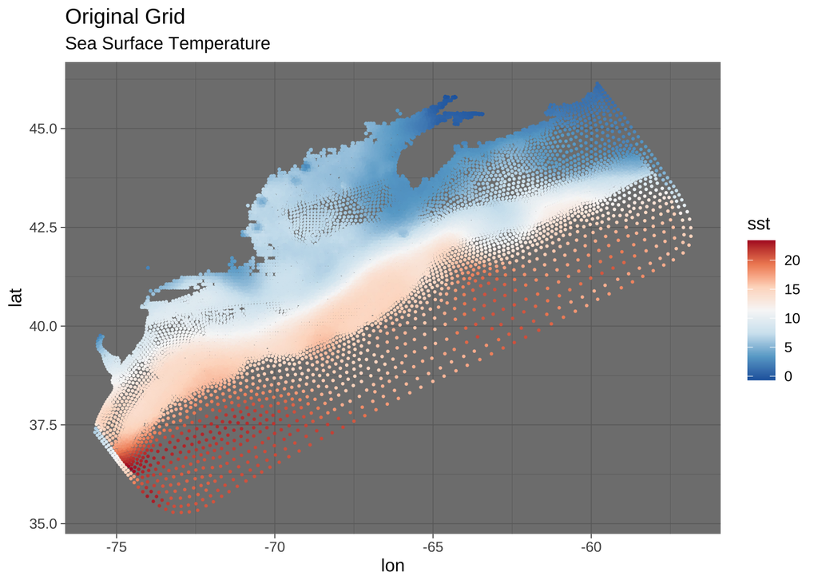

```r
# Plot something
ggplot() +
  # geom_sf(data = gom3_mesh, fill = NA, color = "white", linewidth = 0.1) +
  geom_point(data = node_sst, aes(lon, lat, color = sst), size = 0.35) +
  scale_color_distiller(palette = "RdBu") +
  scale_fill_distiller(palette = "RdBu") +
  scale_shape_manual(values = c(17, 21)) +
  theme_dark() +
  labs(title = "Original Grid",
       subtitle = "Sea Surface Temperature")
```

And this figure below shoes what the interpolated values would be if given regularly spaced coordinates.

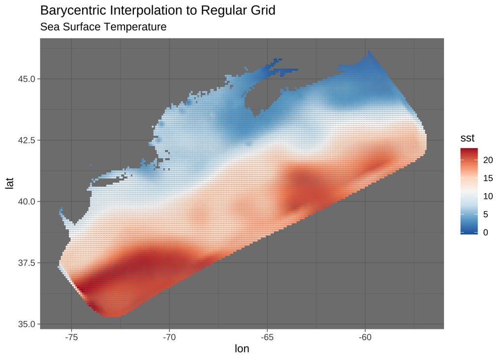

```r
# And the regular grid
ggplot() +
  geom_point(data = interpolated_vals, aes(lon, lat, color = sst), size = 0.35) +
  scale_color_distiller(palette = "RdBu") +
  scale_shape_manual(values = c(17, 21)) +
  theme_dark() +
  labs(title = "Barycentric Interpolation to Regular Grid",
       subtitle = "Sea Surface Temperature")
```

## FVCOM Daily Product Matching

There are a number of projects where biological samples are taken, but environmental conditions might not also be taken simultaneously. This adds the additional step of needing to index to the correct point in time and pull the correct node values associated with it.

For the years 2017-2023 we can use NECOFS forecast data, which uses the GOM4 mesh.